# Sacred Values Signal Trustworthiness — Reproducibility Pipeline (Study 6)

Within-subjects test: a broad halo in, a narrow harm door out

Sacred Values project

Knitted 09 August 2026

# 1 What this document is

This pipeline reproduces, from the raw OSF long-format data, the three Study 6 results the paper reports: the **main effect** of sacred condition on trustworthiness, the **moral halo** (the sacred display raising perceived sacralization on every foundation), and the **multilevel parallel mediation** showing perceived Harm to be the dominant route to trust.

> **Runtime.** The multilevel mediation uses a clustered bootstrap (5,000 resamples on 4,860 rows) and takes ~3 minutes; it is **cached** (`_rmd_cache/study-6/`), so re-knits are instant. The `lavaan` “variance ratio” note (mediators on a 0–1 scale, trust on 0–100) is benign and suppressed inside the fitting function.

# 2 Setup

```r
suppressPackageStartupMessages({
  library(haven)       # read SPSS .sav
  library(dplyr)       # data manipulation
  library(lme4)        # mixed models
  library(lmerTest)    # Satterthwaite ANOVA for lmer
  library(car)         # Type III ANOVA (first-block between-subjects models)
  library(effectsize)  # partial eta-squared
  library(lavaan)      # multilevel parallel mediation
  library(coin)        # exact-distribution Mann-Whitney (standardized Z) for SI block tables
  library(ggplot2)
  library(tibble)
  library(knitr)
})
set.seed(20260619)
N_BOOT    <- 5000L
BOOT_SEED <- 2024L
```

```r
find_data_root <- function(start = getwd(), marker = "data") {
  d <- normalizePath(start, winslash = "/", mustWork = FALSE)
  repeat {
    if (dir.exists(file.path(d, marker))) return(d)
    parent <- dirname(d)
    if (identical(parent, d))
      stop("Could not locate the 'data' directory from ", start, call. = FALSE)
    d <- parent
  }
}
s6_file <- file.path(find_data_root(), "data", "Study 6 - Sacralization of Moral Foundations",
                     "OSF SV Trust - Study 6 Long Dataset.sav")
stopifnot("Study 6 .sav not found" = file.exists(s6_file))
cat("Study 6 data:\n  ", s6_file, "\n")
```

```
## Study 6 data:
##    /Users/thandfie/Library/CloudStorage/Dropbox/Toby-Ji-shared-folder/Sacred Values Experiment/paper/PNAS version/sacred-values-reproducibility/data/Study 6 - Sacralization of Moral Foundations/OSF SV Trust - Study 6 Long Dataset.sav
```

## 2.1 Helper functions

```r
# Five foundations -> their perceived-sacralization columns
S6_MEDS <- c(Harm = "Harm_Sacred_Prop", Fairness = "Fair_Sacred_Prop",
             Authority = "Auth_Sacred_Prop", Loyalty = "Loya_Sacred_Prop",
             Purity = "Pure_Sacred_Prop")

# Multilevel parallel-mediation syntax (5 competing mediators)
# Alongside the five indirect effects we declare the TOTAL effect (c' + sum a*b),
# each foundation's share of that total effect (prop%d), and the overall
# proportion mediated -- so the manuscript's "X% of the trust effect" anchoring
# is bootstrapped here rather than computed by hand.
ml_med_syntax <- function(dv, iv, mediators) {
  k <- seq_along(mediators)
  paste(
    sprintf("%s ~ %s + c*%s", dv, paste(sprintf("b%d*%s", k, mediators), collapse = " + "), iv),
    paste(sprintf("%s ~ a%d*%s", mediators, k, iv), collapse = "\n"),
    paste(sprintf("ind%d := a%d*b%d", k, k, k), collapse = "\n"),
    sprintf("total_indirect := %s", paste(sprintf("a%d*b%d", k, k), collapse = " + ")),
    "total_effect := c + total_indirect",
    paste(sprintf("prop%d := ind%d/total_effect", k, k), collapse = "\n"),
    "prop_mediated := total_indirect/total_effect",
    sep = "\n")
}

# Fit clustered bootstrap mediation
fit_ml_med <- function(data, dv, iv, mediators, cluster, n_boot = N_BOOT, seed = BOOT_SEED) {
  set.seed(seed)
  fit <- suppressWarnings(lavaan::sem(
    ml_med_syntax(dv, iv, mediators), data = data, cluster = cluster,
    se = "bootstrap", bootstrap = n_boot))
  pe <- lavaan::parameterEstimates(fit, ci = TRUE, boot.ci.type = "perc", standardized = TRUE)
  list(fit = fit, pe = pe, mediators = mediators, labels = names(mediators))
}

tidy_indirect <- function(res) {
  k  <- seq_along(res$mediators)
  pe <- res$pe[match(sprintf("ind%d", k), res$pe$label), ]
  pr <- res$pe[match(sprintf("prop%d", k), res$pe$label), ]
  tibble(Foundation = res$labels, B = round(pe$est, 2),
         CI_low = round(pe$ci.lower, 2), CI_high = round(pe$ci.upper, 2),
         Pct_total = round(100 * pr$est, 1),
         Mediates = ifelse(pe$ci.lower > 0 | pe$ci.upper < 0, "yes", "no"))
}

# Total effect (outcome-scale points) with its CI, plus the proportion mediated.
get_total_effect <- function(res) {
  te <- res$pe[res$pe$label == "total_effect", ]
  ti <- res$pe[res$pe$label == "total_indirect", ]
  pm <- res$pe[res$pe$label == "prop_mediated", ]
  list(total = te$est, total_lo = te$ci.lower, total_hi = te$ci.upper,
       indirect = ti$est, prop_mediated = pm$est)
}

# Full decomposition for the SI: mediator M/SD, a-path, b-path, indirect effect,
# its share of the total effect, and the standardized indirect effect.
tidy_decomp <- function(res, data) {
  k   <- seq_along(res$mediators)
  ci  <- function(row) sprintf("[%.2f, %.2f]", row$ci.lower, row$ci.upper)
  a   <- res$pe[match(sprintf("a%d", k), res$pe$label), ]
  b   <- res$pe[match(sprintf("b%d", k), res$pe$label), ]
  ind <- res$pe[match(sprintf("ind%d", k), res$pe$label), ]
  pr  <- res$pe[match(sprintf("prop%d", k), res$pe$label), ]
  med_M  <- vapply(res$mediators, function(v) mean(data[[v]], na.rm = TRUE), numeric(1))
  med_SD <- vapply(res$mediators, function(v) sd(data[[v]],   na.rm = TRUE), numeric(1))
  tibble(Foundation = res$labels,
         M_SD      = sprintf("%.2f (%.2f)", med_M, med_SD),
         a_path    = sprintf("%.3f %s", a$est,   vapply(seq_len(nrow(a)),   function(i) ci(a[i, ]),   "")),
         b_path    = sprintf("%.2f %s",  b$est,   vapply(seq_len(nrow(b)),   function(i) ci(b[i, ]),   "")),
         Indirect  = sprintf("%.2f %s",  ind$est, vapply(seq_len(nrow(ind)), function(i) ci(ind[i, ]), "")),
         Pct_total = sprintf("%.1f%%",   100 * pr$est),
         beta_std  = round(ind$std.all, 3))
}

# Standardized halo (a-path) and trust (b-path) coefficients for the figure betas
tidy_paths_std <- function(res) {
  k  <- seq_along(res$mediators)
  a  <- res$pe[match(sprintf("a%d", k), res$pe$label), ]
  b  <- res$pe[match(sprintf("b%d", k), res$pe$label), ]
  tibble(Foundation = res$labels,
         a_beta = round(a$std.all, 2),  # halo: sacred -> perceived sacralization
         b_beta = round(b$std.all, 2))  # route to trust: sacralization -> trust
}

get_indirect <- function(res, foundation) {
  i  <- match(foundation, res$labels)
  pe <- res$pe[res$pe$label == sprintf("ind%d", i), ]
  c(B = pe$est, lo = pe$ci.lower, hi = pe$ci.upper)
}

audit_row <- function(quantity, computed, claimed, tol, digits = 2) {
  fmt <- function(v) if (is.na(v)) "--" else formatC(v, format = "f", digits = digits)
  check <- if (is.na(claimed)) "not stated"
           else { d <- abs(computed - claimed)
                  if (d <= tol) "match" else if (d <= 3 * tol) "close" else "DIFFERS" }
  tibble(Quantity = quantity, Manuscript = fmt(claimed), Computed = fmt(computed), Check = check)
}
```

## 2.2 Load and prepare

```r
d <- read_sav(s6_file)

# Pre-registered exclusions: keep Exclusions == 0.
ad <- d %>% filter(Exclusions == 0)
ad$FoundationVignette <- factor(as_factor(ad$FoundationVignette))
for (v in c("Trustworthiness", "SV_Condition", unname(S6_MEDS))) ad[[v]] <- as.numeric(ad[[v]])
ad$Participant_ID <- as.factor(ad$Participant_ID)

# Foundation-block labels. FoundationVignette is coded 1-5 with NO value labels in the .sav
# (and the archived author R code never names the levels either). The mapping
# 1=Harm, 2=Fairness, 3=Authority, 4=Loyalty, 5=Purity is NOT guessed: it is recovered
# structurally from the per-participant assignment columns and asserted in the next section
# (see "Data structure"). It is also consistent with each block's between-condition trust Z
# (Harm 24.22, Fairness 20.75, Authority 20.83, Loyalty 21.62, Purity 20.72 --- all exact).
ad$FVcode <- as.numeric(as.character(ad$FoundationVignette))
ad$Block  <- factor(ad$FVcode, levels = 1:5,
                    labels = c("Harm", "Fairness", "Authority", "Loyalty", "Purity"))

n_part <- length(unique(ad$Participant_ID))
cat(sprintf("Rows after exclusion: %d | unique participants: %d\n", nrow(ad), n_part))
```

```
## Rows after exclusion: 4860 | unique participants: 972
```

```r
stopifnot("Study 6 participant count != 972" = n_part == 972L)
table(SV_Condition = ad$SV_Condition)
```

```
## SV_Condition
##    0    1
## 2430 2430
```

# 3 Data structure: what `FoundationVignette` encodes

**Read this before trusting any per-foundation number.** Study 6 is within-subjects: every participant contributes **five rows** to the long dataset, one per moral foundation.

- `FoundationVignette` (1–5) identifies **which foundation** a row’s vignette targeted.
- `SV_Condition` (0/1) is whether that vignette was the **non-sacred** or **sacred** version.
- The randomisation is **within foundation**: each participant is independently assigned to sacred or non-sacred on each of the five foundations. `condition_string` (e.g. `"CTCCT"`) records one participant’s five-way treatment pattern.

**The block $\rightarrow$ foundation mapping is stored implicitly, but is fully recoverable.** The `.sav` gives `FoundationVignette` no value labels, and the author’s archived R code simply `factor()`s the bare integer without naming it. The identity of each block is nonetheless pinned down by the per-participant assignment columns `Harm`, `Fairness`, `Loyalty`, `Authority`, `Purity`, each valued `"<X>_SV"` / `"<X>_NSV"`. Within a given block, the row’s `SV_Condition` must equal that foundation’s assignment. Decoding those columns to 1/0 and checking agreement with `SV_Condition`, **each block matches exactly one foundation at agreement = 1.000** (all others ~0.40). The chunk below performs that check and `stopifnot()`s the labels used above, so any future mislabelling fails the knit loudly rather than silently.

```r
# Structural verification of the block -> foundation mapping (see prose above).
assign_cols <- c(Harm = "Harm", Fairness = "Fairness", Loyalty = "Loyalty",
                 Authority = "Authority", Purity = "Purity")
decode01 <- function(x) {                          # "<X>_SV" -> 1, "<X>_NSV" -> 0
  s <- as.character(haven::as_factor(x))
  ifelse(grepl("NSV", s), 0L, ifelse(grepl("SV", s), 1L, NA_integer_))
}
assign01 <- sapply(assign_cols, function(cn) decode01(ad[[cn]]))
# rows = block (FVcode 1-5); cols = foundation; the 1.000 cell in each row names the block.
agree <- sapply(names(assign_cols),
                function(f) tapply(assign01[, f] == ad$SV_Condition, ad$FVcode, mean, na.rm = TRUE))
kable(round(agree, 3),
      caption = "Agreement of each block's SV_Condition with each foundation's per-participant sacred/non-sacred assignment. The 1.000 cell identifies the block's foundation; ~0.40 elsewhere.")
```

Agreement of each block’s SV_Condition with each foundation’s per-participant sacred/non-sacred assignment. The 1.000 cell identifies the block’s foundation; ~0.40 elsewhere.

| Harm | Fairness | Loyalty | Authority | Purity |
| --- | --- | --- | --- | --- |
| 1.000 | 0.398 | 0.401 | 0.398 | 0.397 |
| 0.398 | 1.000 | 0.398 | 0.399 | 0.402 |
| 0.398 | 0.399 | 0.410 | 1.000 | 0.402 |
| 0.401 | 0.398 | 1.000 | 0.410 | 0.393 |
| 0.397 | 0.402 | 0.393 | 0.402 | 1.000 |

```r
derived <- colnames(agree)[apply(agree, 1, which.max)]
stopifnot("Block->foundation mapping does not match the labels used in `prep`" =
          identical(derived, c("Harm", "Fairness", "Authority", "Loyalty", "Purity")))
cat("Verified mapping (agreement = 1.000 per block):\n",
    "  1 = Harm, 2 = Fairness, 3 = Authority, 4 = Loyalty, 5 = Purity\n", sep = "")
```

```
## Verified mapping (agreement = 1.000 per block):
##   1 = Harm, 2 = Fairness, 3 = Authority, 4 = Loyalty, 5 = Purity
```

# 4 The main effect of sacred condition

A mixed model with the sacred manipulation, foundation, and their interaction, with a random intercept per participant; Type III ANOVA with Satterthwaite degrees of freedom, and partial $\eta^2$.

```r
m_trust <- lmer(Trustworthiness ~ SV_Condition * FoundationVignette + (1 | Participant_ID),
                data = ad)
av  <- anova(m_trust)
eta <- eta_squared(m_trust, partial = TRUE)

sv_F   <- av["SV_Condition", "F value"]
sv_df2 <- av["SV_Condition", "DenDF"]
sv_eta <- eta$Eta2_partial[eta$Parameter == "SV_Condition"]

cat(sprintf("Main effect of sacred condition: F(1, %.1f) = %.2f, p < .001, partial eta^2 = %.2f\n",
            sv_df2, sv_F, sv_eta))
```

```
## Main effect of sacred condition: F(1, 4035.3) = 4929.55, p < .001, partial eta^2 = 0.55
```

```r
kable(as.data.frame(av), digits = 2, caption = "Type III ANOVA (Satterthwaite) for trustworthiness.")
```

Type III ANOVA (Satterthwaite) for trustworthiness.

|  | Sum Sq | Mean Sq | NumDF | DenDF | F value | Pr(>F) |
| --- | --- | --- | --- | --- | --- | --- |
| SV_Condition | 1621838.43 | 1621838.43 | 1 | 4035.30 | 4929.55 | 0 |
| FoundationVignette | 41636.28 | 10409.07 | 4 | 4401.21 | 31.64 | 0 |
| SV_Condition:FoundationVignette | 28528.60 | 7132.15 | 4 | 4728.48 | 21.68 | 0 |

## 4.1 Common-language effect size (probability of superiority)

Partial $\eta^2$ is the right effect size for the mixed model, but it is not comparable to the CLES reported for the between-subjects Studies 1–2 and 4–5. For that cross-study comparison we also compute the **probability that a randomly drawn sacred-condition trust rating exceeds a randomly drawn non-sacred one** (ties counted as half), pooled over all observations. Because Study 6 is within-subjects, this pools non-independent rows: it is a descriptive probability of superiority, and is the reason the manuscript reports a CLES **but not** a rank-biserial *r* for Study 6 — an *r* = *Z*/$\sqrt{N}$ would misuse the repeated-measures *N*.

```r
prob_superiority <- function(high, low) {
  high <- high[!is.na(high)]; low <- low[!is.na(low)]
  mean(outer(high, low, function(a, b) (a > b) + 0.5 * (a == b)))
}
s6_cles <- with(ad, prob_superiority(Trustworthiness[SV_Condition == 1],
                                     Trustworthiness[SV_Condition == 0]))
cat(sprintf("Study 6 trust CLES (pooled over observations) = %.2f  (manuscript: 0.90).\n",
            s6_cles))
```

```
## Study 6 trust CLES (pooled over observations) = 0.90  (manuscript: 0.90).
```

# 5 The moral halo (per-foundation main effects)

Does the sacred display raise perceived sacralization on *every* foundation? One mixed model per foundation.

```r
halo_lmer <- do.call(rbind, lapply(names(S6_MEDS), function(nm) {
  f <- as.formula(sprintf("%s ~ SV_Condition * FoundationVignette + (1 | Participant_ID)",
                          S6_MEDS[[nm]]))
  a <- anova(lmer(f, data = ad))
  data.frame(Foundation = nm, F_SV_condition = a["SV_Condition", "F value"],
             p = a["SV_Condition", "Pr(>F)"])
}))
kable(halo_lmer, digits = 3, caption = "Halo: main effect of sacred condition on each foundation's perceived sacralization.")
```

Halo: main effect of sacred condition on each foundation’s perceived sacralization.

| Foundation | F_SV_condition | p |
| --- | --- | --- |
| Harm | 4163.259 | 0 |
| Fairness | 2767.371 | 0 |
| Authority | 3338.086 | 0 |
| Loyalty | 2821.699 | 0 |
| Purity | 2953.103 | 0 |

```r
cat(sprintf("Foundations raised by the sacred display: %d of 5.\n", sum(halo_lmer$p < .05)))
```

```
## Foundations raised by the sacred display: 5 of 5.
```

# 6 Multilevel parallel mediation

All five perceived-sacralization scores enter as competing mediators of trust, with a clustered bootstrap to respect the repeated-measures structure.

```r
s6_med <- fit_ml_med(ad, "Trustworthiness", "SV_Condition", S6_MEDS, cluster = "Participant_ID")
```

## 6.1 Routes to trust (indirect effects)

```r
kable(tidy_indirect(s6_med),
      caption = "Study 6: indirect effects of each foundation on trustworthiness (clustered bootstrap, percentile CIs).")
```

Study 6: indirect effects of each foundation on trustworthiness (clustered bootstrap, percentile CIs).

| Foundation | B | CI_low | CI_high | Pct_total | Mediates |
| --- | --- | --- | --- | --- | --- |
| Harm | 9.36 | 8.27 | 10.45 | 25.4 | yes |
| Fairness | 1.59 | 0.66 | 2.55 | 4.3 | yes |
| Authority | 1.26 | 0.25 | 2.24 | 3.4 | yes |
| Loyalty | 0.09 | -0.85 | 1.03 | 0.3 | no |
| Purity | -0.24 | -0.98 | 0.50 | -0.7 | no |

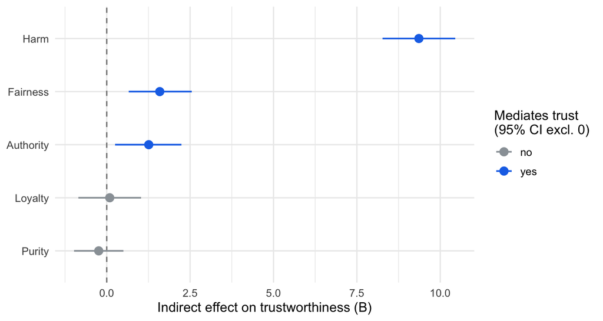

Study 6: indirect effects of the five foundations on trustworthiness (clustered bootstrap 95% CIs). Blue = CI excludes zero. Harm dominates.

```r
fd <- tidy_indirect(s6_med)
fd$Foundation <- factor(fd$Foundation, levels = rev(s6_med$labels))
ggplot(fd, aes(B, Foundation, colour = Mediates)) +
  geom_vline(xintercept = 0, linetype = 2, colour = "grey50") +
  geom_pointrange(aes(xmin = CI_low, xmax = CI_high), linewidth = 0.7, size = 0.6) +
  scale_colour_manual(values = c(no = "#9aa0a6", yes = "#1a73e8"),
                      name = "Mediates trust\n(95% CI excl. 0)") +
  labs(x = "Indirect effect on trustworthiness (B)", y = NULL) +
  theme_minimal(base_size = 12)
```

## 6.2 Anchoring: total effect and each pathway’s share

The raw indirect `B` sits on the 0–100 trust scale. Anchoring it: the **total effect** of the sacred display on trust in scale points, the **proportion mediated** by the five foundations jointly, and each foundation’s indirect effect as a **share of the total effect**. The perceived-sacralization mediators are on a **0–1** scale (proportion of a foundation’s items judged non-negotiable), so the a-paths read as a shift along that scale.

```r
s6_te <- get_total_effect(s6_med)
cat(sprintf(
  "Study 6 total effect on trust: %.1f points (0-100 scale).\n  Mediated jointly: %.1f points = %.0f%% of the total (rest is a direct path).\n",
  s6_te$total, s6_te$indirect, 100 * s6_te$prop_mediated))
```

```
## Study 6 total effect on trust: 36.9 points (0-100 scale).
##   Mediated jointly: 12.1 points = 33% of the total (rest is a direct path).
```

```r
kable(tidy_decomp(s6_med, ad),
      caption = "Study 6 decomposition (SI): mediator M (SD) on the 0-1 scale, a-path, b-path, indirect effect, its share of the total effect, and the standardized indirect effect.")
```

Study 6 decomposition (SI): mediator M (SD) on the 0-1 scale, a-path, b-path, indirect effect, its share of the total effect, and the standardized indirect effect.

| Foundation | M_SD | a_path | b_path | Indirect | Pct_total | beta_std |
| --- | --- | --- | --- | --- | --- | --- |
| Harm | 0.44 (0.42) | 0.505 [0.49, 0.52] | 18.52 [16.47, 20.56] | 9.36 [8.27, 10.45] | 25.4% | 0.173 |
| Fairness | 0.25 (0.36) | 0.379 [0.36, 0.40] | 4.19 [1.74, 6.70] | 1.59 [0.66, 2.55] | 4.3% | 0.029 |
| Authority | 0.30 (0.38) | 0.424 [0.41, 0.44] | 2.98 [0.59, 5.29] | 1.26 [0.25, 2.24] | 3.4% | 0.023 |
| Loyalty | 0.26 (0.37) | 0.395 [0.38, 0.41] | 0.24 [-2.18, 2.59] | 0.09 [-0.85, 1.03] | 0.3% | 0.002 |
| Purity | 0.37 (0.40) | 0.406 [0.39, 0.43] | -0.60 [-2.42, 1.23] | -0.24 [-0.98, 0.50] | -0.7% | -0.005 |

## 6.3 Standardized paths (Fig. 4 betas: broad halo in, narrow door out)

```r
kable(tidy_paths_std(s6_med),
      caption = "Standardized coefficients: a_beta = sacred -> perceived sacralization (the halo); b_beta = sacralization -> trust (the route).")
```

Standardized coefficients: a_beta = sacred -> perceived sacralization (the halo); b_beta = sacralization -> trust (the route).

| Foundation | a_beta | b_beta |
| --- | --- | --- |
| Harm | 0.60 | 0.29 |
| Fairness | 0.53 | 0.06 |
| Authority | 0.56 | 0.04 |
| Loyalty | 0.53 | 0.00 |
| Purity | 0.51 | -0.01 |

## 6.4 Discriminant validity of the five mediators (collinearity, relative weights, dominance)

Because the five foundations are near-collinear, the competing-mediator **b-paths** partition their shared variance in a collinearity-sensitive way (this is what produces suppression and inflates the winning pathway’s apparent margin). We corroborate Harm’s dominance with two order-independent, suppression-free decompositions of the model $R^2$ — Johnson’s (2000) **relative weights** and Budescu’s (1993) **general dominance**, cluster-bootstrapped on participant — and report **VIFs** to quantify the collinearity. Note that the b-path ratio (“~6x the next pathway”) shrinks under this decomposition to roughly 2x: relative weights return to Fairness and Authority the shared variance the partialling had stripped from them. Harm remains the single largest contributor with a bootstrap CI that does not overlap any other foundation.

```r
source(file.path(find_data_root(), "scripts", "R", "collinearity_helpers.R"))

s6_rw <- collinearity_table(as.data.frame(ad), "Trustworthiness",
                            unname(S6_MEDS), names(S6_MEDS),
                            cluster = "Participant_ID", seed = 2024L)
kable(s6_rw, caption = sprintf(
  "Study 6: relative importance of the five foundations for trust ($R^2$ = %.3f), cluster-bootstrapped on participant. RW_pct = Johnson relative weight (%% of $R^2$); Dominance_pct = general dominance (%% of $R^2$); RW_lo/hi = bootstrap 95%% CI on the relative-weight share. A sign flip between r_trust and beta_partial is a suppression tell.",
  attr(s6_rw, "R2")))
```

Study 6: relative importance of the five foundations for trust ($R^2$ = 0.412), cluster-bootstrapped on participant. RW_pct = Johnson relative weight (% of $R^2$); Dominance_pct = general dominance (% of $R^2$); RW_lo/hi = bootstrap 95% CI on the relative-weight share. A sign flip between r_trust and beta_partial is a suppression tell.

|  | Foundation | r_trust | beta_partial | VIF | RW_pct | Dominance_pct | RW_lo | RW_hi |
| --- | --- | --- | --- | --- | --- | --- | --- | --- |
| Harm_Sacred_Prop | Harm | 0.625 | 0.447 | 2.62 | 36.9 | 37.9 | 34.3 | 39.5 |
| Fair_Sacred_Prop | Fairness | 0.535 | 0.063 | 3.93 | 16.9 | 16.8 | 15.6 | 18.3 |
| Auth_Sacred_Prop | Authority | 0.538 | 0.126 | 3.69 | 17.5 | 17.5 | 16.1 | 19.0 |
| Loya_Sacred_Prop | Loyalty | 0.518 | 0.033 | 3.97 | 14.8 | 14.8 | 13.5 | 16.1 |
| Pure_Sacred_Prop | Purity | 0.483 | 0.029 | 2.35 | 13.9 | 13.0 | 12.2 | 15.8 |

# 7 Audit: computed vs manuscript

```r
h <- get_indirect(s6_med, "Harm")
f <- get_indirect(s6_med, "Fairness")
a <- get_indirect(s6_med, "Authority")
std <- tidy_paths_std(s6_med)
halo_betas <- std$a_beta
harm_bbeta <- std$b_beta[std$Foundation == "Harm"]
s6_ind <- tidy_indirect(s6_med)
s6_te  <- get_total_effect(s6_med)

s6_audit <- bind_rows(
  audit_row("Main effect F (SV condition)",  sv_F,   4929.55, 5.0, 2),
  audit_row("Main effect partial eta^2",     sv_eta, 0.55,    0.01, 2),
  audit_row("Trust CLES (pooled)",           s6_cles, 0.90,   0.01, 2),
  audit_row("Total effect on trust (pts)",   s6_te$total, 36.9, 0.3, 1),
  audit_row("Prop. mediated (%)",            100*s6_te$prop_mediated, 33, 2, 0),
  audit_row("Harm indirect B",               h["B"], 9.36,    0.1, 2),
  audit_row("Harm % of total effect",        s6_ind$Pct_total[s6_ind$Foundation=="Harm"], 25, 2, 0),
  audit_row("Harm 95% CI lower",             h["lo"],8.31,    0.5, 2),
  audit_row("Harm 95% CI upper",             h["hi"],10.38,   0.5, 2),
  audit_row("Fairness indirect B",           f["B"], 1.58,    0.1, 2),
  audit_row("Authority indirect B",          a["B"], 1.26,    0.1, 2),
  audit_row("Harm b-path beta",              harm_bbeta, 0.29, 0.02, 2)
)
kable(s6_audit, align = "lrrl")
```

| Quantity | Manuscript | Computed | Check |
| --- | --- | --- | --- |
| Main effect F (SV condition) | 4929.55 | 4929.55 | match |
| Main effect partial eta^2 | 0.55 | 0.55 | match |
| Trust CLES (pooled) | 0.90 | 0.90 | match |
| Total effect on trust (pts) | 36.9 | 36.9 | match |
| Prop. mediated (%) | 33 | 33 | match |
| Harm indirect B | 9.36 | 9.36 | match |
| Harm % of total effect | 25 | 25 | match |
| Harm 95% CI lower | 8.31 | 8.27 | match |
| Harm 95% CI upper | 10.38 | 10.45 | match |
| Fairness indirect B | 1.58 | 1.59 | match |
| Authority indirect B | 1.26 | 1.26 | match |
| Harm b-path beta | 0.29 | 0.29 | match |

```r
cat(sprintf("Halo a-path betas range: %.2f to %.2f (manuscript: .51 to .60).\n",
            min(halo_betas), max(halo_betas)))
```

```
## Halo a-path betas range: 0.51 to 0.60 (manuscript: .51 to .60).
```

```r
ind <- tidy_indirect(s6_med)
cat("Mediates trust:", paste(ind$Foundation[ind$Mediates == "yes"], collapse = ", "),
    "\n  (manuscript: Harm dominant; Fairness and Authority small but significant; Loyalty and Purity null.)\n")
```

```
## Mediates trust: Harm, Fairness, Authority
##   (manuscript: Harm dominant; Fairness and Authority small but significant; Loyalty and Purity null.)
```

# 8 SI results

Reproductions of the Study 6 Supporting Information tables: normality, the between-condition Mann-Whitney tests within each foundation block (`tbl:s6-*-mwu`), the within-block intercorrelations (`tbl:s6-*-corr`), and the condition x foundation interaction.

```r
# Between-condition Mann-Whitney contrast within a block: descriptives, standardized Z,
# effect size r = Z/sqrt(N) (each block is between-subjects), and CLES (prob. of superiority).
basic_contrast <- function(data, iv, dv, label) {
  x <- as.numeric(data[[iv]]); y <- as.numeric(data[[dv]])
  ok <- !is.na(x) & !is.na(y); x <- x[ok]; y <- y[ok]
  g  <- factor(x, levels = c(0, 1), labels = c("Non-sacred", "Sacred"))
  N  <- length(y); n1 <- sum(x == 0); n2 <- sum(x == 1)
  wt <- coin::wilcox_test(y ~ g, distribution = "asymptotic")
  Z  <- abs(as.numeric(coin::statistic(wt, type = "standardized")))
  w  <- stats::wilcox.test(y ~ g, exact = FALSE, correct = FALSE)
  U1 <- as.numeric(w$statistic); U2 <- n1 * n2 - U1
  r_full <- Z / sqrt(N)   # from the UNROUNDED Z: inside tibble() the rounded Z column
                          # would mask the outer Z, biasing boundary cells (e.g. .5349 -> .54)
  tibble(Outcome = label,
         M_sacred = round(mean(y[x == 1]), 2), SD_sacred = round(sd(y[x == 1]), 2),
         Mdn_sacred = round(median(y[x == 1]), 2),
         M_nonsac = round(mean(y[x == 0]), 2), SD_nonsac = round(sd(y[x == 0]), 2),
         Mdn_nonsac = round(median(y[x == 0]), 2),
         n_sacred = n2, n_nonsac = n1,
         U = max(U1, U2), Z = round(Z, 2), p = signif(coin::pvalue(wt), 2),
         r = round(r_full, 2),
         CLES = round(prob_superiority(y[x == 1], y[x == 0]), 2))
}

shapiro_table <- function(data, vars) {
  do.call(rbind, lapply(seq_along(vars), function(i) {
    z <- as.numeric(data[[vars[i]]]); z <- z[!is.na(z)]; sw <- shapiro.test(z)
    tibble(Variable = names(vars)[i], W = round(unname(sw$statistic), 2),
           p = signif(sw$p.value, 2), N = length(z))
  }))
}

star <- function(p) ifelse(p < .001, "***", ifelse(p < .01, "**", ifelse(p < .05, "*", "")))
intercorr_table <- function(data, vars) {
  lab <- names(vars); k <- length(vars)
  X <- sapply(vars, function(v) as.numeric(data[[v]]))
  M <- matrix("", k, k, dimnames = list(sprintf("%d. %s", seq_len(k), lab), paste0(seq_len(k), ".")))
  for (i in seq_len(k)) for (j in seq_len(i)) {
    if (i == j) { M[i, j] <- "--"; next }
    ct <- suppressWarnings(cor.test(X[, i], X[, j]))
    M[i, j] <- sprintf("%.2f%s", ct$estimate, star(ct$p.value))
  }
  out <- tibble::as_tibble(M, rownames = "Variable")
  out$Mean <- round(colMeans(X, na.rm = TRUE), 2)
  out$SD   <- round(apply(X, 2, sd, na.rm = TRUE), 2)
  out
}

# Foundation-block correlation variable set (SI table column order).
S6_IC_VARS <- c(Trust = "Trustworthiness", Harm = "Harm_Sacred_Prop", Fairness = "Fair_Sacred_Prop",
                Authority = "Auth_Sacred_Prop", Loyalty = "Loya_Sacred_Prop", Purity = "Pure_Sacred_Prop")
```

## 8.1 SI: normality (Shapiro-Wilk, Harm block)

The SI reports Shapiro-Wilk tests within the Harm block (non-normality is similar across blocks).

```r
kable(shapiro_table(dplyr::filter(ad, Block == "Harm"),
                    c(Trustworthiness = "Trustworthiness", Harm = "Harm_Sacred_Prop",
                      Fairness = "Fair_Sacred_Prop", Authority = "Auth_Sacred_Prop",
                      Loyalty = "Loya_Sacred_Prop", Purity = "Pure_Sacred_Prop")),
      caption = "Study 6 Harm-block Shapiro-Wilk tests (SI). SI: trust W=.95, harm .75, fairness .66, authority .71, loyalty .65, purity .76.")
```

Study 6 Harm-block Shapiro-Wilk tests (SI). SI: trust W=.95, harm .75, fairness .66, authority .71, loyalty .65, purity .76.

| Variable | W | p | N |
| --- | --- | --- | --- |
| Trustworthiness | 0.95 | 0 | 972 |
| Harm | 0.75 | 0 | 972 |
| Fairness | 0.66 | 0 | 972 |
| Authority | 0.71 | 0 | 972 |
| Loyalty | 0.65 | 0 | 972 |
| Purity | 0.76 | 0 | 972 |

## 8.2 SI: between-condition Mann-Whitney within each block (`tbl:s6-*-mwu`)

For each foundation block, trustworthiness and the five perceived sacralizations contrasted between the sacred and non-sacred conditions (between-subjects within the block).

```r
s6_mwu <- setNames(lapply(levels(ad$Block), function(bl) {
  sub  <- dplyr::filter(ad, Block == bl)
  vars <- c(Trustworthiness = "Trustworthiness", Harm = "Harm_Sacred_Prop",
            Fairness = "Fair_Sacred_Prop", Authority = "Auth_Sacred_Prop",
            Loyalty = "Loya_Sacred_Prop", Purity = "Pure_Sacred_Prop")
  do.call(rbind, lapply(seq_along(vars),
    function(i) basic_contrast(sub, "SV_Condition", vars[i], names(vars)[i])))
}), levels(ad$Block))
for (bl in names(s6_mwu)) {
  cat("\n\n### ", bl, " block\n\n", sep = "")
  print(kable(s6_mwu[[bl]][, c("Outcome","M_sacred","SD_sacred","M_nonsac","SD_nonsac",
                               "n_sacred","n_nonsac","U","Z","p","r","CLES")],
              caption = sprintf("Study 6 %s block: between-condition Mann-Whitney tests (tbl:s6-%s-mwu).",
                                bl, tolower(bl))))
}
```

### 8.2.1 Harm block

Study 6 Harm block: between-condition Mann-Whitney tests (tbl:s6-harm-mwu).

| Outcome | M_sacred | SD_sacred | M_nonsac | SD_nonsac | n_sacred | n_nonsac | U | Z | p | r | CLES |
| --- | --- | --- | --- | --- | --- | --- | --- | --- | --- | --- | --- |
| Trustworthiness | 79.31 | 17.21 | 33.48 | 19.96 | 492 | 480 | 224070.0 | 24.22 | <2.220446e-16 | 0.78 | 0.95 |
| Harm | 0.74 | 0.33 | 0.07 | 0.21 | 492 | 480 | 214085.0 | 23.70 | <2.220446e-16 | 0.76 | 0.91 |
| Fairness | 0.40 | 0.37 | 0.03 | 0.15 | 492 | 480 | 188304.5 | 18.79 | <2.220446e-16 | 0.60 | 0.80 |
| Authority | 0.44 | 0.38 | 0.07 | 0.19 | 492 | 480 | 183927.5 | 16.96 | <2.220446e-16 | 0.54 | 0.78 |
| Loyalty | 0.40 | 0.40 | 0.05 | 0.17 | 492 | 480 | 179217.5 | 16.43 | <2.220446e-16 | 0.53 | 0.76 |
| Purity | 0.52 | 0.39 | 0.13 | 0.26 | 492 | 480 | 181825.5 | 15.73 | <2.220446e-16 | 0.50 | 0.77 |

### 8.2.2 Fairness block

Study 6 Fairness block: between-condition Mann-Whitney tests (tbl:s6-fairness-mwu).

| Outcome | M_sacred | SD_sacred | M_nonsac | SD_nonsac | n_sacred | n_nonsac | U | Z | p | r | CLES |
| --- | --- | --- | --- | --- | --- | --- | --- | --- | --- | --- | --- |
| Trustworthiness | 76.51 | 21.96 | 40.13 | 21.13 | 479 | 493 | 208852.5 | 20.75 | <2.220446e-16 | 0.67 | 0.88 |
| Harm | 0.76 | 0.36 | 0.19 | 0.29 | 479 | 493 | 202699.0 | 20.46 | <2.220446e-16 | 0.66 | 0.86 |
| Fairness | 0.48 | 0.40 | 0.05 | 0.15 | 479 | 493 | 189876.5 | 18.62 | <2.220446e-16 | 0.60 | 0.80 |
| Authority | 0.52 | 0.40 | 0.08 | 0.20 | 479 | 493 | 190318.0 | 18.24 | <2.220446e-16 | 0.59 | 0.81 |
| Loyalty | 0.49 | 0.40 | 0.05 | 0.17 | 479 | 493 | 191757.5 | 19.16 | <2.220446e-16 | 0.61 | 0.81 |
| Purity | 0.56 | 0.40 | 0.17 | 0.28 | 479 | 493 | 181062.5 | 15.32 | <2.220446e-16 | 0.49 | 0.77 |

### 8.2.3 Authority block

Study 6 Authority block: between-condition Mann-Whitney tests (tbl:s6-authority-mwu).

| Outcome | M_sacred | SD_sacred | M_nonsac | SD_nonsac | n_sacred | n_nonsac | U | Z | p | r | CLES |
| --- | --- | --- | --- | --- | --- | --- | --- | --- | --- | --- | --- |
| Trustworthiness | 78.22 | 17.47 | 45.57 | 20.88 | 483 | 489 | 209237.0 | 20.83 | <2.220446e-16 | 0.67 | 0.89 |
| Harm | 0.71 | 0.38 | 0.27 | 0.33 | 483 | 489 | 187693.5 | 16.68 | <2.220446e-16 | 0.53 | 0.79 |
| Fairness | 0.50 | 0.41 | 0.09 | 0.20 | 483 | 489 | 185760.0 | 17.11 | <2.220446e-16 | 0.55 | 0.79 |
| Authority | 0.59 | 0.39 | 0.11 | 0.23 | 483 | 489 | 193510.0 | 18.57 | <2.220446e-16 | 0.60 | 0.82 |
| Loyalty | 0.56 | 0.40 | 0.08 | 0.20 | 483 | 489 | 194348.0 | 19.13 | <2.220446e-16 | 0.61 | 0.82 |
| Purity | 0.62 | 0.40 | 0.22 | 0.31 | 483 | 489 | 181331.5 | 15.17 | <2.220446e-16 | 0.49 | 0.77 |

### 8.2.4 Loyalty block

Study 6 Loyalty block: between-condition Mann-Whitney tests (tbl:s6-loyalty-mwu).

| Outcome | M_sacred | SD_sacred | M_nonsac | SD_nonsac | n_sacred | n_nonsac | U | Z | p | r | CLES |
| --- | --- | --- | --- | --- | --- | --- | --- | --- | --- | --- | --- |
| Trustworthiness | 76.61 | 18.66 | 38.04 | 22.73 | 492 | 480 | 212683.0 | 21.62 | <2.220446e-16 | 0.69 | 0.90 |
| Harm | 0.61 | 0.39 | 0.21 | 0.32 | 492 | 480 | 181386.0 | 15.28 | <2.220446e-16 | 0.49 | 0.77 |
| Fairness | 0.45 | 0.39 | 0.05 | 0.17 | 492 | 480 | 189060.5 | 18.33 | <2.220446e-16 | 0.59 | 0.80 |
| Authority | 0.57 | 0.37 | 0.07 | 0.19 | 492 | 480 | 201985.0 | 20.80 | <2.220446e-16 | 0.67 | 0.86 |
| Loyalty | 0.45 | 0.41 | 0.06 | 0.18 | 492 | 480 | 183715.5 | 17.07 | <2.220446e-16 | 0.55 | 0.78 |
| Purity | 0.58 | 0.40 | 0.18 | 0.30 | 492 | 480 | 181944.0 | 15.46 | <2.220446e-16 | 0.50 | 0.77 |

### 8.2.5 Purity block

Study 6 Purity block: between-condition Mann-Whitney tests (tbl:s6-purity-mwu).

| Outcome | M_sacred | SD_sacred | M_nonsac | SD_nonsac | n_sacred | n_nonsac | U | Z | p | r | CLES |
| --- | --- | --- | --- | --- | --- | --- | --- | --- | --- | --- | --- |
| Trustworthiness | 74.98 | 17.34 | 43.72 | 20.60 | 484 | 488 | 208776.5 | 20.72 | <2.220446e-16 | 0.66 | 0.88 |
| Harm | 0.66 | 0.38 | 0.20 | 0.31 | 484 | 488 | 189549.0 | 17.25 | <2.220446e-16 | 0.55 | 0.80 |
| Fairness | 0.37 | 0.38 | 0.07 | 0.19 | 484 | 488 | 172875.0 | 14.53 | <2.220446e-16 | 0.47 | 0.73 |
| Authority | 0.42 | 0.39 | 0.09 | 0.22 | 484 | 488 | 178171.0 | 15.57 | <2.220446e-16 | 0.50 | 0.75 |
| Loyalty | 0.38 | 0.40 | 0.06 | 0.19 | 484 | 488 | 173032.0 | 14.87 | <2.220446e-16 | 0.48 | 0.73 |
| Purity | 0.57 | 0.39 | 0.12 | 0.25 | 484 | 488 | 191725.0 | 18.09 | <2.220446e-16 | 0.58 | 0.81 |